# Probabilistic incertitude analysis

2016-03-20

This vignette shows how to transform the deterministic Markov model presented in `vignette("homogeneous", "heemod")` in a probabilistic model.

# Model definition

We will start by re-specifying the deterministic models of HIV therapy described previously (a model for monotherapy `mono` and a model for combined therapy `comb`).

But instead of defining transition probabilities and state values directly in `define_matrix()` or `define_state()` (as in the previous vignette), parameters will be defined first in a `define_parameters()` step. This is because only parameters defined this way can be resampled in a probabilistic analysis.

We have to define common parameters in both models because during probabilistic analysis resampled parameters are replaced for both models. So we cannot have `p_AB = 0.202` in model `mono` and `p_AB = 0.202 * rr` in model `comb`, because if we resample the base transition rate to a new value `p_AB'` we will have `p_AB = p_AB'` in both models, instead of what we expect (`p_AB = p_AB' * rr` in model `comb`).

To avoid that problem we use `p_XX_base` parameters that are the ones that will be resampled.

```r
param_mono <- define_parameters(
  rr = .509,

  p_AB_base = .202,
  p_AC_base = .067,
  p_AD_base = .010,

  p_BC_base = .407,
  p_BD_base = .012,

  p_CD_base = .250,


  p_AB = p_AB_base,
  p_AC = p_AC_base,
  p_AD = p_AD_base,

  p_BC = p_BC_base,
  p_BD = p_BD_base,

  p_CD = p_CD_base,

  p_AA = 1 - (p_AB + p_AC + p_AD),

  cost_zido = 2278,
  cost_lami = 2086,

  cost_A = 2756,
  cost_B = 3052,
  cost_C = 9007
)
```

We can then define transition probabilities in the `comb` model according to base transition probabilities.

```r
param_comb <- modify(
  param_mono,

  p_AB = p_AB_base * rr,
  p_AC = p_AC_base * rr,
  p_AD = p_AD_base * rr,

  p_BC = p_BC_base * rr,
  p_BD = p_BD_base * rr,

  p_CD = p_CD_base * rr
)
```

We cannot use the complement alias `C` to specify `p_AA` because we will need to resample that value. Only parameters defined with `define_parameters()` can be resampled.

```r
mat_trans <- define_matrix(
  p_AA, p_AB, p_AC, p_AD,
  .000, C,    p_BC, p_BD,
  .000, .000, C,    p_CD,
  .000, .000, .000, 1.00
)
```

```
## No named state -> generating names.
```

State definition remains the same. in this example.

```r
A_mono <- define_state(
  cost_health = cost_A,
  cost_drugs = cost_zido,
  cost_total = discount(cost_health + cost_drugs, .06),
  life_year = 1
)
B_mono <- define_state(
  cost_health = cost_B,
  cost_drugs = cost_zido,
  cost_total = discount(cost_health + cost_drugs, .06),
  life_year = 1
)
C_mono <- define_state(
  cost_health = cost_C,
  cost_drugs = cost_zido,
  cost_total = discount(cost_health + cost_drugs, .06),
  life_year = 1
)
D_mono <- define_state(
  cost_health = 0,
  cost_drugs = 0,
  cost_total = discount(cost_health + cost_drugs, .06),
  life_year = 0
)

A_comb <- define_state(
  cost_health = cost_A,
  cost_drugs = cost_zido + cost_lami,
  cost_total = discount(cost_health + cost_drugs, .06),
  life_year = 1
)
B_comb <- define_state(
  cost_health = cost_B,
  cost_drugs = cost_zido + cost_lami,
  cost_total = discount(cost_health + cost_drugs, .06),
  life_year = 1
)
C_comb <- define_state(
  cost_health = cost_C,
  cost_drugs = cost_zido + cost_lami,
  cost_total = discount(cost_health + cost_drugs, .06),
  life_year = 1
)
D_comb <- define_state(
  cost_health = 0,
  cost_drugs = 0,
  cost_total = discount(cost_health + cost_drugs, .06),
  life_year = 0
)
```

Models must be first defined and run as in a standard deterministic analysis.

```r
mod_mono <- define_model(
  parameters = param_mono,
  transition_matrix = mat_trans,
  A_mono,
  B_mono,
  C_mono,
  D_mono
)
```

```
## No named state -> generating names.
```

```r
mod_comb <- define_model(
  parameters = param_comb,
  transition_matrix = mat_trans,
  A_comb,
  B_comb,
  C_comb,
  D_comb
)
```

```
## No named state -> generating names.
```

```r
res_mod <- run_models(
  mono = mod_mono,
  comb = mod_comb,
  cycles = 20,
  cost = cost_total,
  effect = life_year
)
```

# Define resampling distributions

Now we can define the resampling distributions. The following parameters will be resampled:

- Relative risk.
- Costs (such that cost are always positive).
- Transition probability from AIDS to death.
- The transition probabilities from state A.

- `rr ~ lognormal(mean = .509, sdlog = .173)`

Usually costs are resampled on a gamma distribution, which has the property of being always positive. Shape and scale parameters of the gamma distribution can be calculated from the mean and standard deviation desired in the distribution. Here we assume that mean = variance.

- `cost_A ~ make_gamma(mean = 2756, sd = sqrt(2756))`

Proportions follow a binomial distribution that can be estimated by giving the mean proportion and the size of the sample used to estimate that proportion.

- `p_CD ~ prop(prob = .25, size = 40)`

Finally multinomial distributions are declared with the number of individuals in each group in the sample used to estimate the proportions. These proportions follow a Dirichlet distribution.

- `p_AA + p_AB + p_AC + p_AD ~ multinom(721, 202, 67, 10)`

```r
rsp <- define_resample(
  rr ~ lognormal(mean = .509, sdlog = .173),

  cost_A ~ make_gamma(mean = 2756, sd = sqrt(2756)),
  cost_B ~ make_gamma(mean = 3052, sd = sqrt(3052)),
  cost_C ~ make_gamma(mean = 9007, sd = sqrt(9007)),

  p_CD ~ prop(prob = .25, size = 40),

  p_AA + p_AB + p_AC + p_AD ~ multinom(721, 202, 67, 10)
)
```

# Run probabilistic model

Now that the distributions of parameters are set we can simply run the probabilistic model as follow:

```r
pm <- run_probabilistic(
  model = res_mod,
  resample = rsp,
  N = 1e2
)
```

```
## Running model 'mono'...
```

```
## Running model 'comb'...
```

The results of the analysis can be plotted on the cost-effectiveness plane:

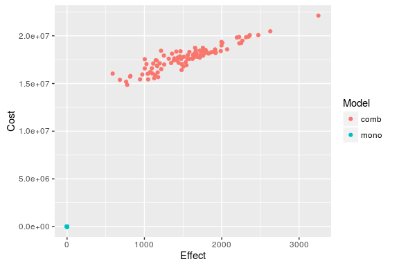

```r
plot(pm, type = "ce")
```

And as cost-effectiveness acceptability curves:

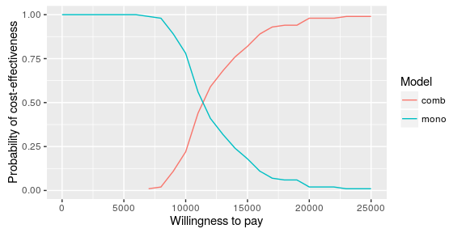

```r
plot(pm, type = "ac", values = seq(0, 25e3, 1e3))
```

As usual plots can be modified with the standard `ggplot2` syntax.

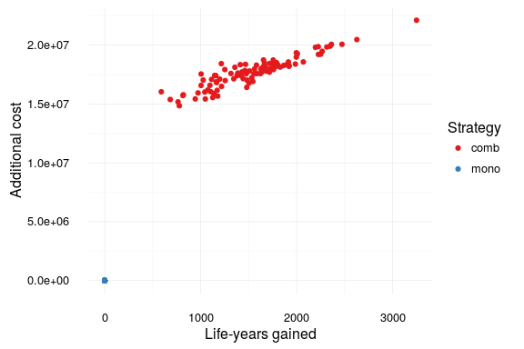

```r
library(ggplot2)

plot(pm, type = "ce") +
  xlab("Life-years gained") +
  ylab("Additional cost") +
  scale_color_brewer(
    name = "Strategy",
    palette = "Set1"
  ) +
  theme_minimal()
```